# Hughes, Statham & Clarke (2024): the fitted model

In Hughes, Statham & Clarke (2024, *Royal Society Open Science*), people foraged for two types of target in **feature** and **conjunction** search, and the experiment varied how scarce each target type was. Here the scarcity levels are pooled, as in the fit, so the two conditions are feature and conjunction foraging. As in other foraging studies, people tend to collect one target type in long runs in conjunction search, and switch more freely in feature search.

This page reads the multi-level Fourier-124 fit made by `../fit_models/fit_models.R` (nothing is refitted here; to fit the model yourself, `fit_hughes2024rsos.R` is the minimal pipeline) and shows how to work with a fitted model: checking convergence, reading the posterior, accuracy and posterior predictive checks. The fit’s settings are the defaults: the default priors, centred distance and class effects, 4 chains of 1000 warmup and 1000 sampling iterations.

Code: `hughes2024rsos.R`.

```r
source("../../../functions/set_up_FoMo.R")
```

```
[1] "set_up_FoMo.R: random seed set to 65 (FOMO_SEED)"
```

```r
source("../fit_models/fit_settings.R")

# the fit this page reads (made by ../fit_models/fit_models.R)
require_example_fits("hughes2024rsos_fourier124")

n_post_draws <- 20   # posterior draws for the posterior predictive check
```

## 1 The data

```r
# feature and conjunction foraging, pooled over the scarcity levels
# (scarcity = FALSE), as fitted
d <- import_dataset("hughes2024rsos")

d$stim |>
  summarise(people = n_distinct(person), trials = n_distinct(trial),
            items_per_trial = n() / n_distinct(trial), .by = condition) |>
  left_join(summarise(d$found, selections = n(), .by = condition), by = "condition") |>
  knitr::kable()
```

| condition | people | trials | items_per_trial | selections |
| --- | --- | --- | --- | --- |
| conjunction | 36 | 1080 | 20 | 21600 |
| feature | 36 | 1080 | 20 | 21600 |

One random trial from each condition. Items are coloured by target type; the line is the order the targets were selected in.

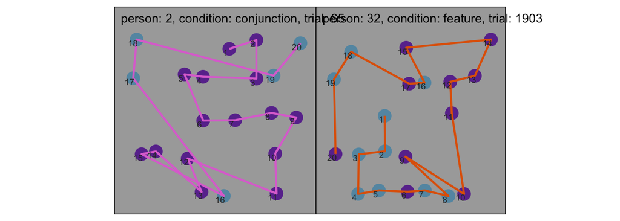

Figure 1: One trial per condition: items and selection order.

```r
plot_trial(d$found, d$stim)
```

How long people kept selecting the same target type before switching (runs): the main difference between the conditions.

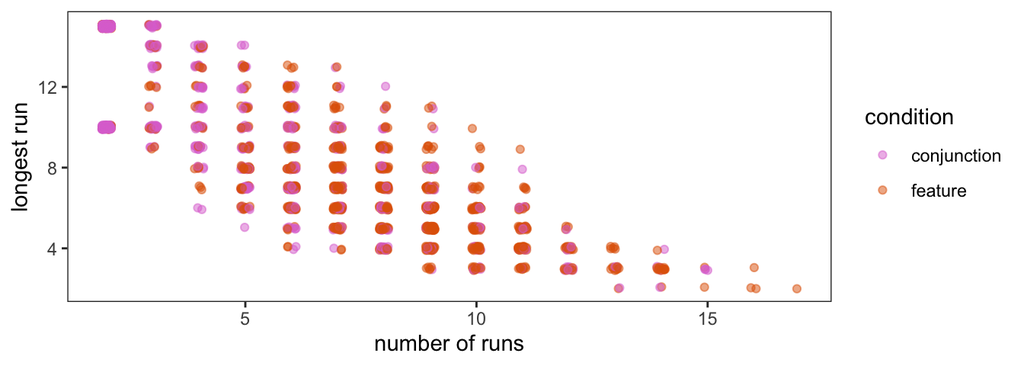

Figure 2: Run lengths by condition.

```r
plot_runs(compute_runs(d$found))
```

Per-trial statistics, used below to check the fitted model against the data.

```r
trial_stats <- compute_trial_stats(d$found)
head(trial_stats) |> knitr::kable(digits = 2)
```

| person | condition | n_found | best_r | mean_itd | pao | n_runs | max_run_length |
| --- | --- | --- | --- | --- | --- | --- | --- |
| 1 | conjunction | 20 | 0.64 | 0.32 | 48.8 | 5.27 | 9.80 |
| 1 | feature | 20 | 0.83 | 0.25 | 20.6 | 6.93 | 7.90 |
| 2 | conjunction | 20 | 0.58 | 0.30 | 45.6 | 3.97 | 11.07 |
| 2 | feature | 20 | 0.92 | 0.25 | 18.2 | 8.93 | 5.87 |
| 3 | conjunction | 20 | 0.45 | 0.33 | 53.2 | 2.10 | 13.33 |
| 3 | feature | 20 | 0.91 | 0.25 | 19.0 | 9.00 | 6.00 |

## 2 The fit

```r
# the fit, and the data list it was made from (fits from before Oct 7
# 2026 don't carry their own: prep_example_sl() rebuilds it with the same
# settings as fit_models.R used)
fit <- readRDS(file.path(FITS_DIR, "hughes2024rsos_fourier124.rds"))
sl <- prep_example_sl(d, "hughes2024rsos", "fourier124")
```

Population-level estimates (medians and 97% HPDIs) and convergence. R-hat and ESS are coloured green (good), orange (acceptable) or red (bad). This fit mixed less well than most: its largest R-hat is about 1.03 and its smallest bulk ESS about 185 at 1000 iterations. That’s usable for medians and intervals, but a published analysis should rerun it with 2000 iterations.

```r
fomo_summary(fit, cond_labels = levels(d$stim$condition))
```

**Fixed effects (median and 97% HPDI)**

| parameter | condition | component | lower | median | upper | rhat | ess_bulk | ess_tail |
| --- | --- | --- | --- | --- | --- | --- | --- | --- |
| rho_delta | conjunction |  | 0.92 | 0.97 | 1.03 | 1.00 | 3463 | 2837 |
| rho_delta | feature |  | 1.25 | 1.37 | 1.48 | 1.00 | 3777 | 3105 |
| rho_psi | conjunction |  | -0.32 | -0.10 | 0.12 | 1.00 | 1179 | 2074 |
| rho_psi | feature |  | -0.70 | -0.36 | 0.02 | 1.00 | 552 | 829 |
| fourier_coef | conjunction | h1 cos | -0.22 | -0.13 | -0.03 | 1.00 | 830 | 1498 |
| fourier_coef | feature | h1 cos | -0.45 | -0.29 | -0.12 | 1.02 | 342 | 672 |
| fourier_coef | conjunction | h1 sin | 0.28 | 0.59 | 0.87 | 1.01 | 227 | 293 |
| fourier_coef | feature | h1 sin | 0.66 | 1.13 | 1.55 | 1.03 | 185 | 296 |
| fourier_coef | conjunction | h2 cos | 0.54 | 0.71 | 0.91 | 1.01 | 310 | 687 |
| fourier_coef | feature | h2 cos | 0.39 | 0.56 | 0.72 | 1.01 | 267 | 484 |
| fourier_coef | conjunction | h2 sin | 0.04 | 0.11 | 0.18 | 1.00 | 1588 | 2370 |
| fourier_coef | feature | h2 sin | 0.05 | 0.13 | 0.20 | 1.00 | 1565 | 2413 |
| fourier_coef | conjunction | h4 cos | 0.32 | 0.42 | 0.51 | 1.00 | 671 | 1367 |
| fourier_coef | feature | h4 cos | 0.33 | 0.42 | 0.52 | 1.01 | 573 | 1030 |
| fourier_coef | conjunction | h4 sin | -0.01 | 0.04 | 0.09 | 1.00 | 2740 | 2701 |
| fourier_coef | feature | h4 sin | -0.01 | 0.04 | 0.08 | 1.00 | 3817 | 2676 |
| b_v | conjunction | 1,1 | 2.67 | 3.72 | 4.80 | 1.00 | 3868 | 2713 |
| b_v | feature | 1,1 | 0.59 | 0.94 | 1.27 | 1.00 | 4542 | 3156 |
| b_v | conjunction | 2,1 | -3.73 | -2.89 | -1.99 | 1.00 | 4699 | 2966 |
| b_v | feature | 2,1 | -1.68 | -1.20 | -0.71 | 1.00 | 4149 | 2552 |

Convergence (all parameters): largest R-hat 1.033 (fourier_coef[2,2]); smallest bulk ESS 185 (fourier_coef[2,2]), tail ESS 293 (fourier_coef[1,2]); 0 divergent transitions.

Rank plots of the five worst-mixing parameters. If the chains have mixed well, each chain’s histogram is roughly flat and they overlap.

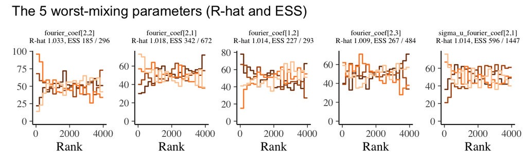

```r
plot_post_traces(fit)
```

## 3 Posterior

`extract_post()` turns the fit’s draws into tidy tables (one per group of parameters), which the `plot_post_*()` functions take.

```r
post <- extract_post(fit, d$found, d$stim)
```

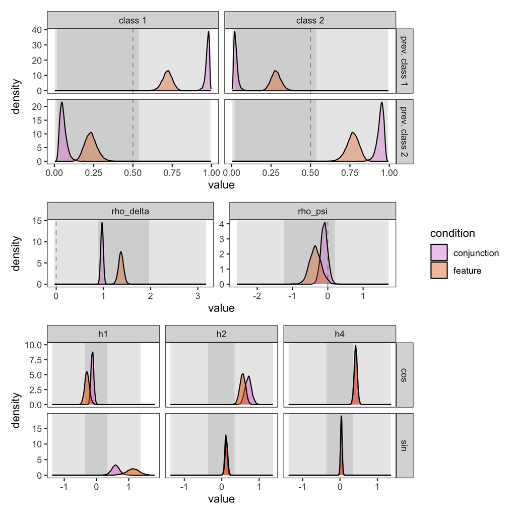

Figure 4: Posterior densities by condition: class transitions, distance and relative direction, and the Fourier coefficients. Grey bands: the priors’ HPDIs.

```r
plot_post(post)
```

The same spatial parameters, shown as what each does to an item’s selection weight:

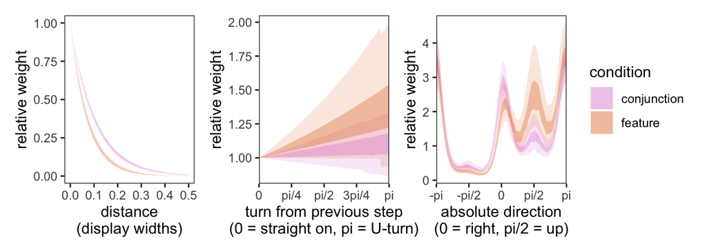

Figure 5: Relative selection weight against distance, turn and absolute direction: 53% and 97% HPDIs.

```r
plot_post_spatial(post, show = "weights")
```

Each person’s distance and relative-direction estimates, over the population’s:

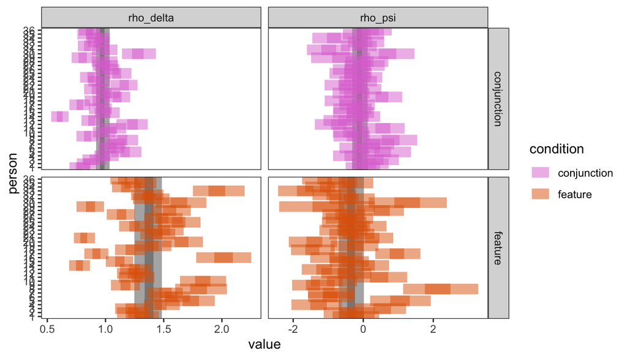

Figure 6: Per-person estimates (intervals) over the population-level HPDIs (grey bands).

```r
plot_post_per_person_spatial(post)
```

And each person’s class-transition probabilities: how likely they are to select each target type next, given the type they just selected. With two types each row of the matrix sums to one, so the columns come in mirrored pairs.

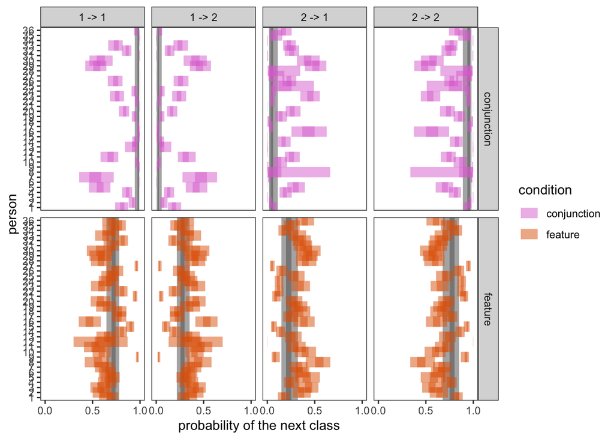

Figure 7: Per-person class-transition probabilities (previous type -> next type) over the population-level HPDIs (grey bands).

```r
plot_post_per_person_cat(post)
```

## 4 Accuracy

The fit doesn’t store a prediction for every selection (`save_selections = FALSE`, the default), so `predict_fomo()` makes them from 200 posterior draws. Deterministic accuracy is how often the item the model judges most likely is the one selected; the probability of the chosen item credits being nearly right too. Chance (dotted) is 1 / items left; the nearest-neighbour rule (dashed) always picks the closest item, so the gap above it is what the model adds to proximity alone. This is in-sample accuracy, which overestimates out-of-sample accuracy.

```r
# the fit doesn't store per-selection predictions (save_selections =
# FALSE), so predict them for a subset of draws
pred <- predict_fomo(fit, sl, n_draws = 200)
acc <- extract_post(pred, d$found, d$stim)$acc
```

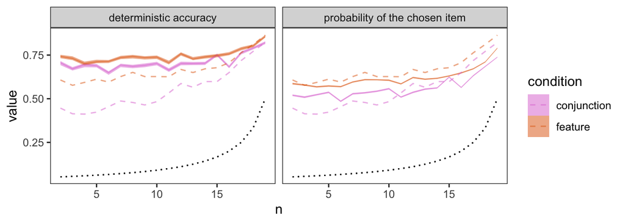

Figure 8: Accuracy at each selection, with chance and nearest-neighbour baselines.

```r
plot_post_accuracy(acc, d$stim, d$found)
```

## 5 Posterior predictive check

Whole trials simulated from the fitted model, compared with the data. The model doesn’t predict when a trial stops, so each simulated trial keeps as many selections as the observed one.

```r
# whole trials simulated from the fit; the model doesn't predict when a
# trial stops, so keep as many simulated selections as the data have
p <- sim_fomo(sl, fit, iter = n_post_draws)
extract_pred(p, d$stim) |>
  semi_join(d$found, by = c("trial", "n")) -> p2
```

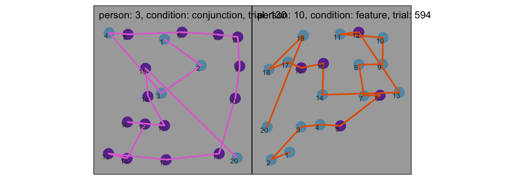

Figure 9: One trial per condition, simulated from the fitted model.

```r
plot_trial(p2, d$stim)
```

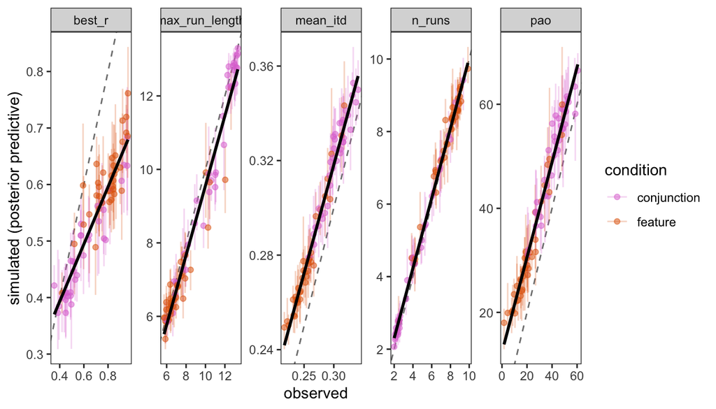

Figure 10: Trial statistics for the data (x) and simulated from the posterior (y). Points near the diagonal mean the model reproduces them.

```r
sim_stats <- compute_trial_stats(p2)
plot_trial_stats(trial_stats, sim_stats)
```

## 6 Model comparison: does scarcity matter?

The fit above pools the three scarcity levels within each task: target type A scarce (5 A and 15 B targets per display), both equal (10 each), or B scarce. The paper asked whether people favour the **scarce** target type, and found no evidence that they do.

The alternative model gives each task x scarcity combination its own condition ($K = 6$), so every parameter can differ with scarcity. The trials and selections are the same, so loo compares the two directly.

```r
# the same trials with each scarcity level its own condition (K = 6: task x
# scarcity), against the main fit (K = 2: task)
d6 <- import_dataset("hughes2024rsos_scarcity")
fit6 <- read_example_fit(d6, "hughes2024rsos_scarcity", "fourier124")
fits <- list(`K = 2` = fit, `K = 6` = fit6)
# loo for each fit, from the per-trial log-likelihoods the fits store
loos <- map(fits, \(f) f$loo())
```

```r
# accuracy needs each fit's data list (sls) to predict the selections
cmp <- fomo_compare(fits, d, loos = loos, n_draws = 200,
                    sls = list(`K = 2` = sl, `K = 6` = attr(fit6, "fomo_sl")))
format_compare(cmp, columns = c("model", "deterministic", "nn", "gain_nn", "elpd", "elpd_diff",
                                "se_diff", "pct_high_k", "robust"))
```

| model | deterministic | nn | gain_nn | elpd | elpd_diff | se_diff | pct_high_k | robust |
| --- | --- | --- | --- | --- | --- | --- | --- | --- |
| K = 2 | 0.728 | 0.607 | 0.120 | -40017 | -525 | 98.1 | 0.6 | TRUE |
| K = 6 | 0.735 | 0.607 | 0.128 | -39492 | 0 | 0.0 | 5.7 | TRUE |

The $K = 6$ model is far ahead on loo (525 $\pm$ 98 elpd), and every cell contributes, including the two *equal* cells, where nothing about scarcity changes:

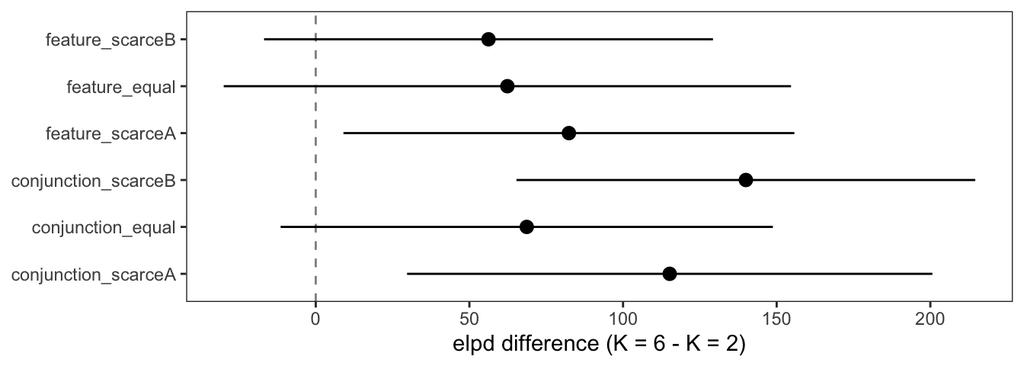

Figure 11: Difference in loo between the $K = 6$ and $K = 2$ models, summed over each task x scarcity cell (point: sum; bars: 2 SE).

```r
# where the difference comes from: by task x scarcity
plot_post_elpd_by_condition(loos[c("K = 6", "K = 2")], d6$stim)
```

But this doesn’t mean scarcity changes behaviour on average. In a multi-level model, separate conditions also give each person separate values in each condition, and loo rewards that whenever individuals behave a little differently from cell to cell, even when the population values are identical (see the `condition_difference` example). So loo answers a different question:

- **Do individuals behave differently across scarcity levels?** Loo: yes, clearly.
- **Does scarcity change behaviour on average?** The posterior of the population differences between the scarcity levels.

*Note*: 5.7% of trials have a high Pareto $k$ in the $K = 6$ fit (0.6% in the $K = 2$ fit), so the size of the loo difference is approximate; the winner is robust to leaving those trials out.

### 6.1 The scarcity bias

For the population question, we use the paper’s parameters (see the single-level cat example): the bias towards class A, $b_a$ (the average of the transition matrix’s two rows’ log-odds of A over B), and the stick/switch rate, $b_s$ (half their difference).

```r
# The paper's parameters (see the single-level cat example): b_a, the bias
# towards class A (1), is the average of the transition matrix's two rows'
# log-odds of class A over class B; b_s, the stick/switch rate, is half
# their difference. Computed for every posterior draw of the population
# values in each task x scarcity condition
post6 <- extract_post(fit6, d6$found, d6$stim)

papers_scale <- post6$cat |>
  filter(dist == "posterior") |>
  select(.draw, condition, prev_class, class, value) |>
  pivot_wider(names_from = class, names_prefix = "p", values_from = value) |>
  mutate(logodds = log(p1 / p2)) |>
  select(.draw, condition, prev_class, logodds) |>
  pivot_wider(names_from = prev_class, names_prefix = "after_", values_from = logodds) |>
  mutate(b_a = (after_1 + after_2) / 2,
         b_s = (after_1 - after_2) / 2) |>
  separate(condition, c("task", "scarcity"), sep = "_")
```

A scarcity bias would push $b_a$ up when A is scarce and down when B is scarce, compared with the equal condition.

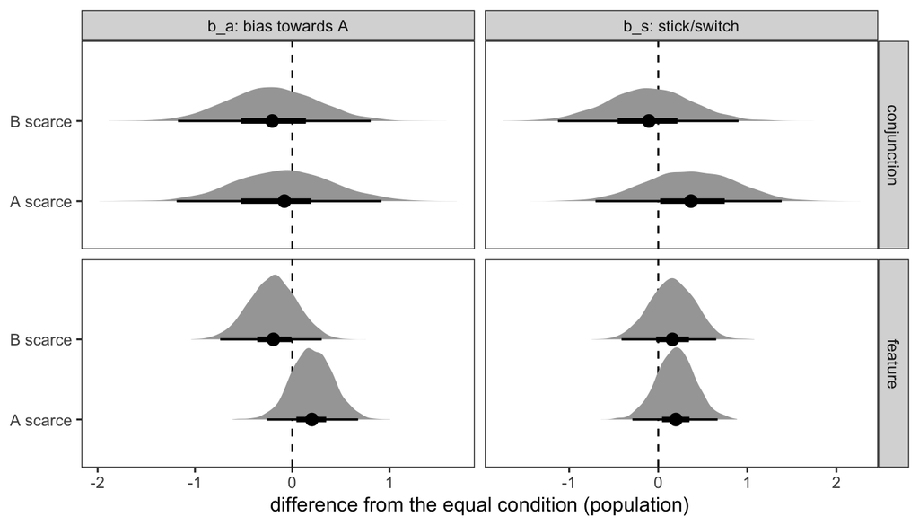

Figure 12: Population $b_a$ (bias towards class A) and $b_s$ (stick/switch rate) in each scarce condition minus the equal condition, by task: medians with 53% and 97% HPDIs. Dashed line: no difference.

```r
# each scarce condition minus the equal one, within each task. A bias
# towards the scarce type would push b_a up when A is scarce and down when
# B is scarce
papers_scale |>
  select(.draw, task, scarcity, b_a, b_s) |>
  pivot_longer(c(b_a, b_s), names_to = "parameter") |>
  pivot_wider(names_from = scarcity) |>
  mutate(`A scarce` = scarceA - equal,
         `B scarce` = scarceB - equal) |>
  pivot_longer(c(`A scarce`, `B scarce`), names_to = "comparison", values_to = "difference") |>
  mutate(parameter = recode(parameter, b_a = "b_a: bias towards A", b_s = "b_s: stick/switch")) |>
  ggplot(aes(difference, comparison)) +
  geom_vline(xintercept = 0, linetype = "dashed") +
  ggdist::stat_halfeye(.width = FOMO_HPDI_WIDTHS, point_interval = "median_hdci") +
  facet_grid(task ~ parameter, scales = "free_x") +
  labs(x = "difference from the equal condition (population)", y = NULL)
```

Every difference is close to 0, with 0 inside its 97% HPDI. In feature search, $b_a$ moves slightly in the predicted direction (A scarce minus B scarce: 0.40, 97% HPDI $-0.16$ to 0.92), but not reliably. Stickiness ($b_s$) doesn’t change with scarcity in either task. This matches the paper: no evidence of a scarcity bias, even though each person’s behaviour varies from one scarcity level to another.